# Problem 3

2023-11-23

1. Use R and ggplot2 package to draw a a plot of number of genes per chromosome in human genomes. This task requires the data file Homo_sapiens.gene.info.gz. You need to use columns 3 and 7 indicating Symbol and chromosome respectively. Save the plot to PDF file.

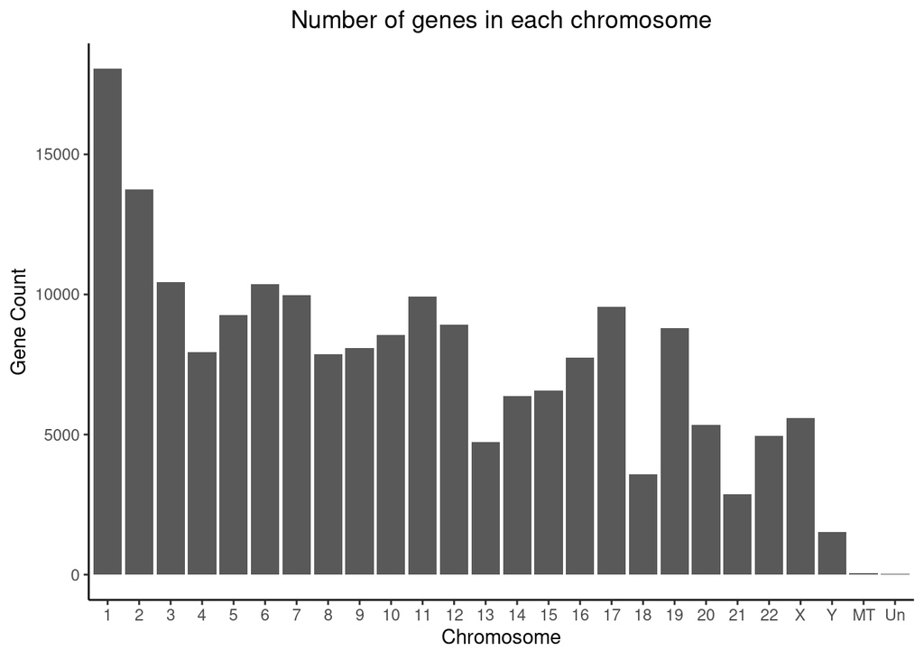

```r
dat <- read.delim("../data/Homo_sapiens.gene_info.gz", header = T)

gpc <- dat |>
  select(Symbol, chromosome) |>
  summarise(.by = chromosome, gene_count = n_distinct(Symbol)) |>
  mutate(chromosome = factor(chromosome,
                             levels = c("1", "2", "3", "4", "5", "6", "7", "8", "9", "10",
                                        "11", "12", "13", "14", "15", "16", "17", "18", "19",
                                        "20", "21", "22", "X", "Y", "MT", "Un"))) |>
  drop_na()

ggplot(gpc, aes(x = chromosome, y = gene_count)) +
  geom_col() +
  labs(y = "Gene Count", x = "Chromosome", title = "Number of genes in each chromosome") +
  theme_classic() +
  theme(plot.title = element_text(hjust = 0.5))
```

```r
# ggsave("num_of_genes_per_chr.pdf", height = 3.5, width = 7, units = "in")
```

2. The longer chromosome might have higher frequency of genes most probably by chance. We will test this hypothesis. You can find the length information of each chromosome here: https://www.ncbi.nlm.nih.gov/grc/human/data. Is there any correlation between number of genes and chromosome length? Also, plot the regression data with the trendline. Calculate the Rˆ2 and other statistics to determine whether the fit is significant. From the regression equation estimate the number of genes expected for each chromosome. Then evaluate whether any chromosome has higher or lower concentration of genes. Hint: Ignore MT and UN. You need to find 95% confidence interval of the regression. Read more about it here: https://rpubs.com/aaronsc32/regression-confidence-prediction-intervals

```r
# download.file("https://ftp.ncbi.nlm.nih.gov/pub/grc/human/GRC/GRCh38.p14_GenBank/GCA_000001405.29_GRCh38.p14_assembly_report.txt", destfile = "GRCh38.p14_assembly_report")

GRCh38 <- read_delim("GRCh38.p14_assembly_report",
    delim = "\t", escape_double = FALSE,
    col_names = FALSE, comment = "#", trim_ws = TRUE)

chr_lens <- GRCh38[1:24,c(3,9)]
names(chr_lens) <- c("chromosome", "length")

full_df <- left_join(chr_lens, gpc, by = "chromosome") |>
  mutate(chromosome = factor(chromosome,
                             levels = c("1", "2", "3", "4", "5", "6", "7", "8", "9", "10",
                                        "11", "12", "13", "14", "15", "16", "17", "18", "19",
                                        "20", "21", "22", "X", "Y")))

cor(x = full_df$length, y = full_df$gene_count)
```

```
## [1] 0.7941247
```

```r
chr_lm <- lm(gene_count ~ length, full_df)
summary(chr_lm)
```

```
##
## Call:
## lm(formula = gene_count ~ length, data = full_df)
##
## Residuals:
##     Min      1Q  Median      3Q     Max
## -3691.1 -1147.7   106.9   750.3  4299.0
##
## Coefficients:
##              Estimate Std. Error t value Pr(>|t|)
## (Intercept) 1.732e+03  1.108e+03   1.563    0.132
## length      4.831e-05  7.883e-06   6.129 3.61e-06 ***
## ---
## Signif. codes:  0 '***' 0.001 '**' 0.01 '*' 0.05 '.' 0.1 ' ' 1
##
## Residual standard error: 2186 on 22 degrees of freedom
## Multiple R-squared:  0.6306, Adjusted R-squared:  0.6138
## F-statistic: 37.56 on 1 and 22 DF,  p-value: 3.613e-06
```

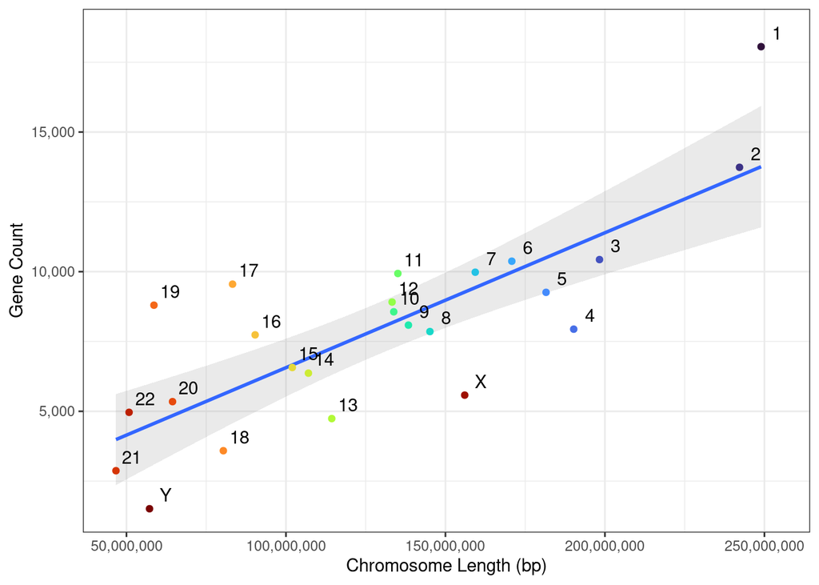

```r
ggplot(full_df, aes(x = length, y = gene_count)) +
  geom_smooth(method = 'lm', formula = 'y ~ x', alpha = 1/5) +
  geom_point(aes(color = chromosome), show.legend = F) +
  labs(y = "Gene Count", x = "Chromosome Length (bp)", color = "Chromosome") +
  scale_x_continuous(labels = scales::number_format(big.mark = ",")) +
  scale_y_continuous(labels = scales::number_format(big.mark = ",")) +
  geom_text(aes(label = chromosome), nudge_x = 5000000, nudge_y = 500) +
  theme_bw() +
  scale_color_viridis_d(option = "turbo")
```

```r
preds <- cbind(full_df, predict(chr_lm, full_df, interval = "confidence", level = 0.95) |> as.data.frame()) |>
  mutate(sig_diff = ifelse(gene_count < lwr | gene_count > upr, TRUE, FALSE))

# chromosomes with gene counts outside of the regression model's 95% confidence intervals
cat(preds$chromosome[which(preds$sig_diff == TRUE)])
```

```
## 1 4 11 13 16 17 18 19 23 24
```

```r
# percentage of chromosomes out of confidence intervals
sum(preds$sig_diff == TRUE)/length(preds$sig_diff)*100
```

```
## [1] 41.66667
```

3. In earlier problem we calculated the frequency of disease variant in each gene in human genome. Can you evaluate whether any human chromosome has more concentration of disease variants?

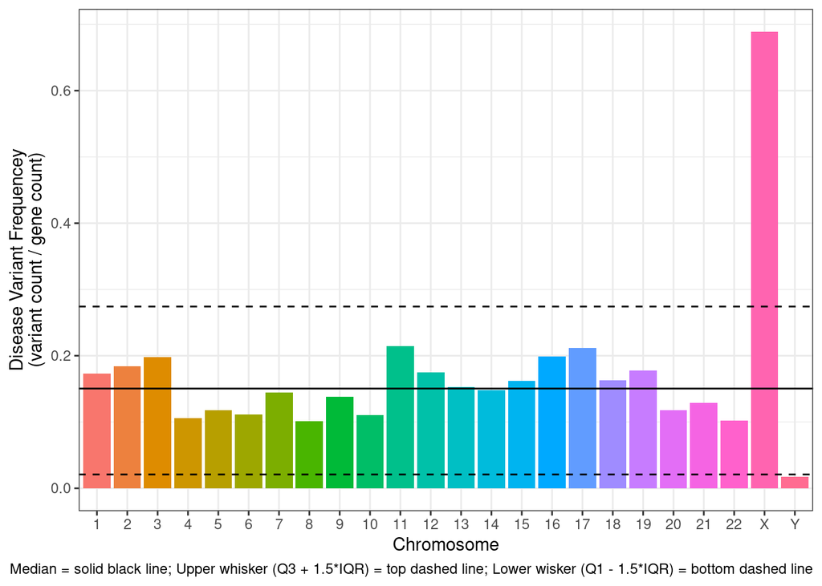

```r
chr_locs <- dat |>
  select(gene_name = Symbol, chromosome)

dis_vars <- read_tsv("../data/dis_vars.tsv") |>
  left_join(chr_locs, by = "gene_name") |>
  mutate(chromosome = factor(chromosome,
                             levels = c("1", "2", "3", "4", "5", "6", "7", "8", "9", "10",
                                        "11", "12", "13", "14", "15", "16", "17", "18", "19",
                                        "20", "21", "22", "X", "Y"))) |>
  summarise(.by = chromosome, var_count = sum(n)) |>
  drop_na() |>
  left_join(full_df, by = "chromosome") |>
  mutate(var_freq = var_count/gene_count)

ggplot(dis_vars, aes(x = chromosome, y = var_freq)) +
  geom_col(aes(fill = chromosome), show.legend = F) +
  geom_hline(yintercept = quantile(dis_vars$var_freq, 0.5, names = F)) +
  geom_hline(yintercept = quantile(dis_vars$var_freq, 0.75, names = F) + IQR(dis_vars$var_freq)*1.5,
             linetype = "dashed") +
  geom_hline(yintercept = quantile(dis_vars$var_freq, 0.25, names = F) - IQR(dis_vars$var_freq)*1.5,
             linetype = "dashed") +
  labs(y = "Disease Variant Frequencey\n(variant count / gene count)", x = "Chromosome",
       caption = "Median = solid black line; Upper whisker (Q3 + 1.5*IQR) = top dashed line; Lower wisker (Q1 - 1.5*IQR) = bottom dashed line") +
  theme_bw()
```

As seen in the plot, the disease variant frequency for chr X is an extreme outlier. In other words: chromosome X has significantly more recorded disease causing mutations relative to its total number of genes when compared to the other chromosomes.